# How Many Psychologists Use Questionable Research Practices? The HTML Version!

Nicholas Fox, Nathan Honeycutt, & Lee Jussim

July 18, 2018

## How Many Psychologists Use Questionable Research Practices? Estimating the Population Size of Current QRP Users

#### Nicholas Fox, Nathan Honeycutt, & Lee Jussim

Department of Psychology, Rutgers University, Piscataway New Jersey, 08854

### Abstract

Psychology has been in crisis. Over the past 15 years many high-impact research findings have failed to replicate, calling into question their validity. Increased methodological and statistical scrutiny has led to field-wide introspection on how best to produce robust, reproducible, research. One focus has been on the use of questionable research practices. Previous estimates of the number of researchers who use questionable research practices vary widely, from over 60% to near 10%. In the current work, the authors produced three estimates of the number of American psychologists who have used questionable research practices in the last 12 months, utilizing direct, indirect, and social network measures of estimation. We estimate up to 24.4% of American psychologists have recently used at least one questionable research practice. These estimates represent the first step in generating actionable interventions to resolve the current replication crisis and increase trust in published research.

### How Many Psychologists Use Questionable Research Practices? Estimating the Population Size of Current QRP Users

It is the researcher’s job to generate theories, test hypotheses, collect and interpret data, interpret results, and to publish findings. This is all done to learn more about the world and how it works. In the course of doing science, the researcher has many decisions to make: How many subjects will I use? How will I operationalize my variables? What is the population of interest that I am studying? Should certain collected observations be excluded?

Each decision point is a “researcher degree of freedom” (Simmons, Nelson, and Simonsohn 2011), with the potential of introducing error and bias. Since there is a high level of ambiguity in research, these degrees of freedom can be resolved in different ways. In reviewing how researchers deal with outlying observations, Simmons, Nelson, and Simonsohn (2011) found different research groups made independent decisions on the best course of action. When researchers cleaned data and removed participants that responded “too fast”, some defined this as 2 standard deviations below the mean response speed, some defined it as observations below 200ms, and others removed the fastest 2.5% of respondents. None of these definitions are inherently an incorrect interpretation of “too fast”, which is the problem: without clear standards in place, this type of flexible decision making can change the overall interpretation of a study’s results.

Although there are some instances when QRP use may be justified, most of times they are used, they are contributing to the false-positive rate seen in the published literature (Fanelli 2009; Banks et al. 2016). Not only can QRP use increase the number of false-positive findings (e.g., taking a “non-significant” result and pushing it over a threshold into being “significant”), but using multiple QRPs can also influence the reported effect size of a given finding due to sampling bias and low power (Button et al. 2013). This can lead to interpretations that are not warranted by the data.

### Prevalence of questionable research practices

Consider one of the most basic questions to ask about the replication crisis: How many people are contributing to it? John, Loewenstein, and Prelec (2012) found 63% of psychologists admitted to publishing work without all the dependent measure included (at some point in their academic career). As articulated by Simmons, Nelson, and Simonsohn (2011), this is highly problematic because increasing the number of dependent variables is correlated with an increase in the probability of finding a significant result. Without reporting all dependent measures, readers are left with a false impression of the rarity or truthfulness of the reported findings. But, this estimate from John, Loewenstein, and Prelec (2012) was contested by Fiedler and Schwarz (2016). In their conceptual replication that used differently worded questions, a different conceptualization of “prevalence”, and tested a German (as opposed to an American) cohort of psychologists, Fiedler and Schwarz (2016) found less than 10% prevalence of the same questionable practice (omitting dependent variables).Further complicating these estimates, Agnoli et al. (2017) recently replicated the original John, Loewenstein, and Prelec (2012) study in an Italian cohort of psychologists, and found similarly high levels of QRP use (47.9% of respondents had omitted dependent variables). There is currently no consensus on the prevalence of QRPs in psychology, nor any indication of how these may be related to the current replication crisis in the field.

Given the inconsistencies in assessing the prevalence of QRPs, the current work sought to expand on the existing literature in two ways. First, we investigated current QRP use, operationalized as using at least one of nine QRPs “in the past 12 months”. This puts QRP use into the frame of the current replication crisis. Second, we generated an estimate of QRP use utilizing the social networks of psychologists. This indirect method, called the generalized network scale up estimator (GNSUM) (M. J. Salganik et al. 2011; Zhang et al. 2010; Zheng, Salganik, and Gelman 2006; Jing et al. 2014), used network information from the general population of psychologists to make size estimates about specific populations existing within. By tapping into the ego networks of participants (Lu et al. 2009), the GNSUM can collect large amounts of data about population members per participant. Additionally, this method did not require participants to identify with a potentially stigmatized group, potentially reducing response bias compared to more traditional direct estimates.

While network scale up estimators were expected to provide insights into QRP use prevalence, they have yet to be used in psychology. The authors assessed the viability of the generalized network scale up estimate in this context, while also estimating QRP use prevalence using more traditional methods - namely, a direct estimate, and the unmatched count technique (UCT). Thus, this work produced three estimates of QRP use prevalence.

### METHOD

The work detailed in this manuscript was preregistered on May 15th, 2017. The preregistration can be found at DOI 10.17605/OSF.IO/XU25N and www.osf.io/xu25n.

### Sample

The frame population was tenured or tenure-track psychologists associated with a PhD-granting institution in the United States. The population contained 7101 individuals as of June 2017. All 7101 members of this population were contacted via email and asked to participate. Of the 7101 email invitations sent, 214 emails bounced (3.01%). We collected 613 full responses (8.63% full response rate), and 296 partial responses. Only full responses are used in the following estimations. Additionally, 26 participant responses were removed for either being marked complete erroneously or due to breaking estimate-specific criteria. There was no compensation offered for participantion, and participants had 7 days to complete the survey after starting. 299 (48.78%) participants identified as female, and 279 (45.51%) identified as male, and 19 (3.1%) choosing not to identify their gender. 131 (21.37%) participants identified as an Assistant Professor, 141 (23%) as Associate Professor, and 208 (33.93%) as Full Professor. 113 participants identified as tenure or tenure-track, but did not disclose their tenure level.

### Data Sources

As data was collected between September 2017 and December 2017, questions framed using “in the past 12 months” constrains actual QRP use between September 2016 and December 2017, a time frame of 15 months. Therefore, estimates of current QRP use are based on the number of psychologists who have used at least one QRP in this time frame.

### Direct Estimate

For comparison to the generalized network scale-up (GNSUM) and unmatched count technique (UCT) estimates, we estimated the number of QRP users by direct estimation. This involveds asking members of the target population whether they have used at least one QRP in the past 12 months, and is calculated as follows:
$$\begin{equation}
\rho = \frac{c}{n}
\end{equation}$$

where $\rho$ is the proportion estimate of people who have used at least one QRP in the past 12 months, $c$ is the number of participants indicating they have used a QRP in the past 12 months, and $n$ is the total number of participant responses.

### Network Scale-Up and Generalized Network Scale-Up Methods

Network scale-up methods estimate population sizes using information about the personal networks (i.e., ego networks) of respondents, based on the assumption that personal networks are, on average, representative of the population (Salganik2011). Participants were asked about how many people they “know” in the frame population. In this study, “know” was defined as: they know you by face or by name, you know them by face or by name, you could contact the person if you wanted to, and you’ve been in contact in the past two years (Bernard2010). Participants were then asked a series of questions to estimate the total size of their social network, and the number of people they know who have used at least one QRP in the past 12 months. Together, the network scale-up can be used to estimate the proportion of QRP users, and was calculated as follows:
$$\begin{equation}
\rho = \frac{\sum y_i}{\sum d_i}
\end{equation}$$

where $\rho$ is the proportion estimate of people who have used at least one QRP in the past 12 months, $y_i$ is the number of people known in the target group $y$ by participant $i$, and $d_i$ is the estimated total number of people known $d$ by participant $i$ within the frame population.

Equation 3 makes two assumptions: that members of the general frame population know all identity information about all members of their ego networks, and that QRP users have the same size social networks as the general frame population. Since QRP use is concealable and potentially stigmatizing, these assumptions may not hold. For that reason, data was collected from self-identifying QRP users to estimate how QRP-use identity information transmits through ego networks (tau, $\tau$, also called the transmission rate). This data was collected using the game of contacts method (Salganik2012). A popularity ratio (delta, $\delta$) was calculated by dividing the average network size of QRP users by the average network size of the general frame population.

Together, $\tau$ and $\delta$ adjust the network scale-up estimate in equation 3 into the generalized network scale-up as follows:
$$\begin{equation}
\rho = \frac{\sum y_i}{\sum d_i} * \frac{1}{\tau} * \frac{1}{\delta}
\end{equation}$$

where $\rho$ is the proportion estimate of people who have used at least one QRP in the past 12 months, $\frac{\sum y_i}{\sum d_i}$ is the network scale-up estimate (equation 3), $\tau$ is the transmission rate, and $\delta$ is the popularity ratio. All network scale-up results are calculated using Equation 4, incorporating $\tau$ and $\delta$.

### Game of Contacts

To estimate the QRP identity transmission rate, $\tau$, we performed the game of contacts with participants who self-identified as using at least one QRP in the past 12 months. For a full description of the game of contacts, see Salganik et al (2012)). Briefly, this method has participants (called egos in network terminology) answer a set of questions about what they know about the QRP use of several others (called alters) in their social network, and what those alters know about the participant’s QRP use. The questions are semi-graphical and responses are recorded on a digital 2x2 grid, representing the four possible ways information can flow through a given ego-alter relationship. The transmission rate is then calculated as:
$$\begin{equation}
\tau = \frac{\sum{w_i}}{\sum{x_i}}
\end{equation}$$

where $w_i$ is the number of alters that know the ego is a member of the target population, and $x_i$ is the total number of alters generated by the ego. This produced a value between 0 and 1.

### Results

The three estimates of recent QRP use in the frame population of American tenured or tenure-track faculty are summarized in Figure 1, and described in detail below.

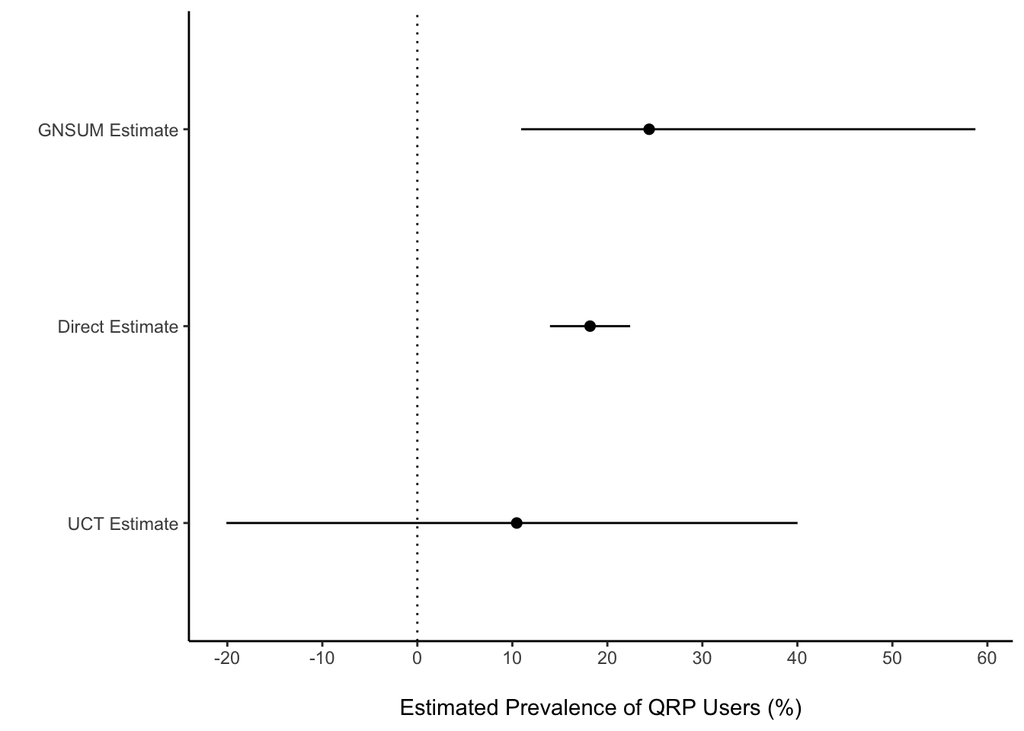

Estimates of the current prevalence of users of questionable research practices using three different estimators; the Generalized Network Scale-Up Method (GNSUM), the Direct Estimate, and the Unmatched Count Technique (UCT). Point estimates with 95% bootstrapped confidence intervals.

### Direct Estimate

To ensure the highest number of participants in our game of contacts, half of the total population were asked to participate in Survey 3, which contained our direct estimate question. Thus,

| emails_sent |
| --- |
| 3551 |

psychologists were solicited, and we received

| analyzed_participants |
| --- |
| 308 |

responses to Survey 3 able to be analyzed. Of the

| analyzed_participants |
| --- |
| 308 |

participants,

| QRP |
| --- |
| 56 |

indicated they had used at least one QRP in the past 12 months. Using Equation 1, we calculated QRP prevalence to be 18.18% (bootstrapped 95% confidence interval [13.96%, 22.4%]). This corresponds to an estimated 1291 American psychologists currently using QRPs.

It is possible this estimate is underestimating the true number of psychologists using QRPs. For one, social desirability may influence QRP users to conceal their identity when asked directly. In that case, our estimate is only generated by those participants willing to reveal their identity. Given the somewhat critical social environment for QRP users (Fiske 2016), it is reasonable to believe some participants withheld their identity when we asked directly. The following indirect estimation methods sought to mitigate this social desirability bias.

### Unmatched Count Technique

The remaining

| sum(emails_sent) |
| --- |
| 3550 |

psychologists contacted were asked to participate in our unmatched count estimate with

| emails_sent |
| --- |
| 1775 |

randomized into the innocuous list condition, and

| emails_sent |
| --- |
| 1775 |

randomized into the sensitive list condition.

The average number of list items corresponding to participants in the innocuous list condition was

| mean |
| --- |
| 4.3 |

. The average number of list items corresponding to participants in the sensitive list condition was

| mean |
| --- |
| 4.4 |

It was unexpected that an UCT estimate lower than our direct estimate would be calculated. Typically, due to reducing response bias, UCT estimates tend to be larger than direct estimates when the behavior or identity in question is stigmatized (Gervais and Najle 2017; Wolter and Laier 2014; Starosta and Earleywine 2014). The fact that the bootstrapped confidence interval crosses zero indicates instibility in the sensitive list being consistantly larger than the control list. It is likely our relatively low number of participants in our UCT estimate (

| sum(analyzed_participants) |
| --- |
| 279 |

) led this calculation to be overly sensitive to individual responses. This is not the first time the UCT has provided smaller estimates than a direct estimate (Arentoft et al. 2016), though given the high variability, we do not have confidence that this UCT estimate is a valid estimate of current QRP use.

### Generalized Network Scale-Up Estimate

All participants who were randomized into the UCT estimate were also asked to answer questions about their social networks, and to estimate how many researchers they know who have used at least one QRP in the past 12 months. Participants who were randomized into the direct estimate and who self-identified as a QRP user in that estimate were also asked to answer questions about their social network and to participate in the game of contacts method. Participants in the direct estimate who did not self-identify as a QRP user were asked questions about their social network as well, but were not asked how many researchers they know who have used at least one QRP in the past 12 months. Therefore, we collected social network responses from

| sum(analyzed_participants) |
| --- |
| 531 |

participants from the general frame population (to be used in estimating $\delta$),

| sum(QRP_USE) |
| --- |
| 56 |

responses from participants who self-identified as QRP users who also completed the game of contacts (to be used in estimating $\tau$), and

| sum(analyzed_participants) |
| --- |
| 279 |

responses from participants who estimated the number of researchers they know who have used at least one QRP in the past 12 months.

These

| sum(analyzed_participants) |
| --- |
| 279 |

identified

| sum(y_i) |
| --- |
| 664 |

QRP users, and know a collective

| sum(d_i) |
| --- |
| 46828 |

researchers. Given the total frame population is 7101, we are fairly confident all members were identified at least once by our participants. Using the network scale-up in Equation 3, this generates an estimate of 1.42% [0.85%, 2.14%]. This estimate serves as the base starting point for Equation 4, the Generalized Network Scale-Up Estimator, detailed below.

Equation 4 relaxes the assumptions of equal network size and total information transmission by incorporating $\tau$ and $\delta$. Using the

| sum(analyzed_participants) |
| --- |
| 531 |

responses from the general population, plus the

| sum(QRP_USE) |
| --- |
| 56 |

responses from the participants who indicated using a QRP in the past 12 months, we estimate $\delta$ as

| mean |
| --- |
| 0.97 |

. Using the game of contacts, we estimate $\tau$ as 0.06. Using Equation 4, we estimate QRP user prevalence to be 24.4% [10.93%, 58.74%]. This corresponds to an estimated 1733 American psychologists currently using QRPs.

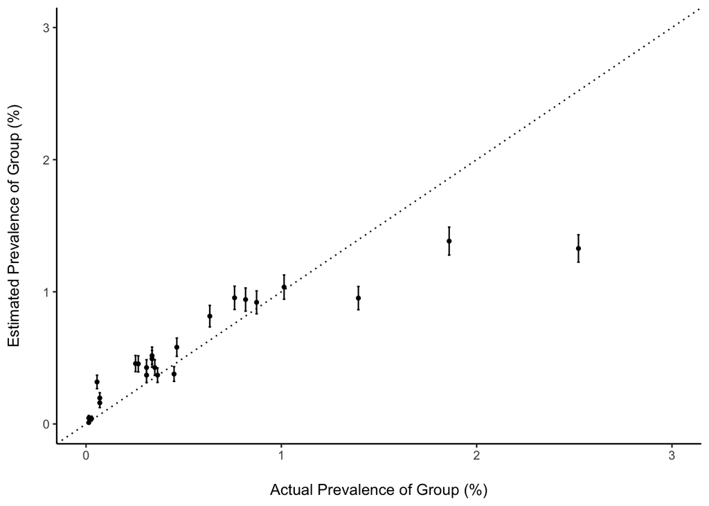

Validation of Network Scale-Up Estimates using 24 groups of known size. Each point represents one group, with 95% confidence intervals. Dotted line represents when estimated group size equals actual group size.

### DISCUSSION

To the best of our knowledge, this is the first report of the prevalence of QRPs in a proximal timespan. As such, it is difficult to draw conclusions about the magnitude of our estimates when compared to previous estimates. Compared to John, Loewenstein, and Prelec (2012) and Agnoli et al. (2017), we estimate lower rates of questionable research practices. Compared to Fiedler and Schwarz (2016), however, we estimate higher rates of these practices. Our definition of “questionable research practices” were the same ones used in John, Loewenstein, and Prelec (2012) and Agnoli et al. (2017), but was restricted to a timespan of only 15 months, so it is reasonable that our estimates would be lower than those with an unrestricted time of QRP use. Since we used those same QRP definitions, is also reasonable that our estimates would be higher than those described by Fiedler and Schwarz (2016), who changed the definition of each QRP. We also measured true “prevalence”, that is, the commonality of a behavior within a designated time frame, which was a point of difference between John, Loewenstein, and Prelec (2012) and Fiedler and Schwarz (2016).

This is also the first report to use the network scale-up and generalized network-scale up estimators to investigate the ongoing reproducibility issues in psychology. Re-framing QRP prevalence away from the individual behavior and towards the user state brings our field-wide problems more into scope with existing literature on stigma and concealable identities. For example, much work has been done focusing on how increasing stigma inadvertently locks individuals into detrimental behaviors (Stuber, Galea, and Link 2009), and how revealing a concealed identity can increase well-being by reducing the stress of being exposed (Chaudoir and Quinn 2010). Framing QRP use in terms of the individual may help the field reduce QRP use by increasing awareness of the effects of stigma and support.

### Limitations & Future Directions

Our unmatched count estimate produced a value with a confidence interval that crossed zero, meaning there was sufficient variance to destabilize the group difference we observed. As mentioned previously, the relatively low number of participants for the unmatched count estimate (

| sum(analyzed_participants) |
| --- |
| 279 |

) contributed to this high variability. Future work using the unmatched count technique would benefit from larger sample sizes (as demonstrated in Gervais and Najle (2017), which used 2000 participants).

# References

Agnoli, Franca, Jelte M. Wicherts, Coosje L S Veldkamp, Paolo Albiero, and Roberto Cubelli. 2017. “Questionable research practices among Italian research psychologists.” *PLoS ONE* 12 (3): 1–17. doi:10.1371/journal.pone.0172792.

Arentoft, Alyssa, Kathleen Van Dyk, April D. Thames, Philip Sayegh, Nicholas Thaler, Daniel Schonfeld, Joseph Labrie, and Charles H. Hinkin. 2016. “Comparing the unmatched count technique and direct self-report for sensitive health-risk behaviors in HIV+ adults.” *AIDS Care - Psychological and Socio-Medical Aspects of AIDS/HIV* 28 (3): 370–75. doi:10.1080/09540121.2015.1090538.

Banks, George C., Ernest H. O’Boyle, Jeffrey M. Pollack, Charles D. White, John H. Batchelor, Christopher E. Whelpley, Kristie A. Abston, Andrew A. Bennett, and Cheryl L. Adkins. 2016. “Questions About Questionable Research Practices in the Field of Management: A Guest Commentary.” *Journal of Management* 42 (1): 5–20. doi:10.1177/0149206315619011.

Benjamin, Daniel J., James O. Berger, Magnus Johannesson, Brian A. Nosek, E. J. Wagenmakers, Richard Berk, and Valen E. Johnson. 2017. “Redefine Statistical Significance.” *PsyArxiv*, no. July 22: 1–18. doi:10.17605/OSF.IO/MKY9J.

Button, Katherine S., John P. A. Ioannidis, Claire Mokrysz, Brian A. Nosek, Jonathan Flint, Emma S. J. Robinson, and Marcus R. Munafò. 2013. “Power failure: why small sample size undermines the reliability of neuroscience.” *Nature Reviews Neuroscience* 14 (5). Nature Publishing Group: 365–76. doi:10.1038/nrn3475.

Chaudoir, Stephenie R., and Diane M. Quinn. 2010. “Revealing Concealable Stigmatized Identities: The Impact of Disclosure Motivations and Positive First-Disclosure Experiences on Fear of Disclosure and Well-Being.” *Journal of Social Issues* 66 (3): 570–84. doi:10.1111/j.1540-4560.2010.01663.x.

Fanelli, Daniele. 2009. “How many scientists fabricate and falsify research? A systematic review and meta-analysis of survey data.” *PLoS ONE* 4 (5). doi:10.1371/journal.pone.0005738.

———. 2018. “Is science really facing a reproducibility crisis, and do we need it to?” *Proceedings of the National Academy of Sciences of the United States of America2* in press: 1–4. doi:10.1073/pnas.1708272114.

Fiedler, Klaus, and Norbert Schwarz. 2016. “Questionable Research Practices Revisited.” *Social Psychological and Personality Science* 7 (1): 45–52. doi:10.1177/1948550615612150.

Fiske, Susan T. 2016. “Mob Rule or Wisdom of Crowds.” *APS Observer*.

Gervais, Will M, and Maxine B Najle. 2017. “How many atheists are there?” *Social Psychological and Personality Science*. SAGE Publications Sage CA: Los Angeles, CA, 1948550617707015.

Jing, Liwei, Chengyi Qu, Hongmei Yu, Tong Wang, and Yuehua Cui. 2014. “Estimating the sizes of populations at high risk for HIV: A comparison study.” *PLoS ONE* 9 (4): 1–6. doi:10.1371/journal.pone.0095601.

John, L. K., G. Loewenstein, and D. Prelec. 2012. “Measuring the Prevalence of Questionable Research Practices With Incentives for Truth Telling.” *Psychological Science* 23 (5): 524–32. doi:10.1177/0956797611430953.

Lakens, Daniel, Federico G Adolfi, Casper J Albers, Farid Anvari, Matthew A J Apps, Shlomo E Argamon, Thom Baguley, et al. 2018. “Justify Your Alpha: A Response to ‘ Redefine Statistical Significance’.” *Nature Human Behavior* 2: 168–71.

Lu, Yu-En, Sam Roberts, Pietro Lio, Robin Dunbar, and Jon Crowcroft. 2009. “Size Matters: Variation in Personal Network Size, Personality and Effect on Information Transmission.” *2009 International Conference on Computational Science and Engineering*, no. 217141: 188–93. doi:10.1109/CSE.2009.179.

Salganik, Matthew J., Dimitri Fazito, Neilane Bertoni, Alexandre H. Abdo, Maeve B. Mello, and Francisco I. Bastos. 2011. “Assessing network scale-up estimates for groups most at risk of HIV/AIDS: Evidence from a multiple-method study of heavy drug users in Curitiba, Brazil.” *American Journal of Epidemiology* 174 (10): 1190–6. doi:10.1093/aje/kwr246.

Simmons, Joseph P., Leif D. Nelson, and Uri Simonsohn. 2011. “False-Positive Psychology.” *Psychological Science* 22 (11): 1359–66. doi:10.1177/0956797611417632.

Starosta, Amy J., and Mitch Earleywine. 2014. “Assessing base rates of sexual behavior using the unmatched count technique.” *Health Psychology and Behavioral Medicine* 2 (1). Taylor & Francis: 198–210. doi:10.1080/21642850.2014.886957.

Stuber, Jennifer, Sandro Galea, and Bruce G. Link. 2009. “Stigma and Smoking: The Consequences of Our Good Intentions.” *Social Service Review* 83 (4): 585–609. doi:10.1086/650349.

Tukey, John W. 1970. *Exploratory Data Analysis*.

Wicherts, Jelte M., Coosje L.S. Veldkamp, Hilde E.M. Augusteijn, Marjan Bakker, Robbie C.M. van Aert, and Marcel A.L.M. van Assen. 2016. “Degrees of freedom in planning, running, analyzing, and reporting psychological studies: A checklist to avoid P-hacking.” *Frontiers in Psychology* 7 (NOV): 1–12. doi:10.3389/fpsyg.2016.01832.

Wolter, Felix, and Bastian Laier. 2014. “The Effectiveness of the Item Count Technique in Eliciting Valid Answers to Sensitive Questions. An Evaluation in the Context of Self-Reported Delinquency.” *Survey Research Methods* 8 (3): 153–68.

Zhang, T Y, I C Hellstrom, R C Bagot, X Wen, J Diorio, and M J Meaney. 2010. “Maternal care and DNA methylation of a glutamic acid decarboxylase 1 promoter in rat hippocampus.” *J Neurosci* 30 (39): 13130–7. doi:10.1523/JNEUROSCI.1039-10.2010.

Zheng, Tian, Matthew J Salganik, and Andrew Gelman. 2006. “How Many People Do You Know in Prison?” *Journal of the American Statistical Association* 101 (474): 409–23. doi:10.1198/016214505000001168.